# Appendix G: Bootstrapping three approaches to fitting biphasic growth models

Kyle L. Wilson The University of Calgary

October 5, 2017

This appendix is in support of Wilson *et al.* (2017). The citation style language (csl) used herein is the methods-in-ecology-and-evolution.csl file which can be downloaded from https://github.com/citation-style-language/styles/blob/master/methods-in-ecology-and-evolution.csl and placed in the same directory as this .rmd file.

## Summary description of objectives:

The following script evaluates 3 different statistical approaches for fitting the Lester biphasic model where the breakpoint (age-at-maturity) is treated as unknown prior to model estimation (Lester, Shuter & Abrams 2004). We use three different sets of initial parameter values to evaluate the sensitivity of each approach to starting values. We repeatedly generate random datasets (i.e., bootstrapping) to evaluate model performance. We compare the approaches using root mean squared error
$$rmse = \sqrt{1/n*\sum_{i=1}^n(L_i-\hat{L_i})^2}$$
and percent bias:
$$Bias = ((\theta_i - \hat{\theta_i})/\theta_i) * 100$$
, which are useful metrics to evaluate model performance (Ono, Punt & Rivot 2012). Users can vary the scenarios and/or the number of bootstraps used (i.e., the `Nbootstraps` object). **Note** 100 iterations took ~24 hours to complete.

The first step is to load the required libraries.

```r
# Load required library
library(boot)  # use install.packages('boot') if package isn't already installed
library(runjags)  #load, install, or require the 'runjags' library
library(rjags)
library(stats4)  #load the 'stats4' library
library(coda)
library(parallel)
```

## Global functions

The global functions defined below are also used in Appendices A-H. For example, the `nll()` function is our penalized negative log-likelihood which we introduced in Appendix C. The profile likelihood approach is similar to that used in (Honsey, Staples & Venturelli 2016).

```r
Corner_text <- function(text, location="topright") #function to write text to the corner of plots
{
  legend(location,legend=text, bty ="n", pch=NA)
}

panel.cor <- function(x, y, digits = 2, prefix = "", cex.cor, ...) #function to change size of text in the pairs plots to match the size of the correlation
{
  usr <- par("usr"); on.exit(par(usr))
  par(usr = c(0, 1, 0, 1))
  r <- abs(cor(x, y))
  txt <- format(c(r, 0.123456789), digits = digits)[1]
  txt <- paste0(prefix, txt)
  if(missing(cex.cor)) cex.cor <- 0.8/strwidth(txt)
  text(0.5, 0.5, txt, cex = cex.cor * r)
}

biphasicPlot <- function(h=h,g=g,t1=t1,Tmat=Tmat) #function to return the biphasic growth trajectory for a given set of parameters
{
  LT_ages <- ages
  juv <- h*(LT_ages-t1)
  adult <- (3*h/g)*(1-exp(-(log(1+g/3))*(LT_ages-(Tmat+log(1-g*(Tmat-t1)/3)/log(1+g/3)))))
  pred <- ifelse(LT_ages<=Tmat,juv,adult)
  return(pred)
}

nll <- function(theta)
{
  h <- theta[1]
  t1 <- theta[2]
  g <- inv.logit(theta[3])
  size.cv <- theta[4]
  T_pred <- theta[5]
  # make conversions to phase 2 VBGF parameters
  linf <- 3*h/g
  vbk <- log(1+g/3)
  t0 <- suppressWarnings(Tmat + log(1-g*(T_pred-t1)/3)/log(1+g/3))

  # Make predictions to the data
  pred1 <- h*(Data$Age-t1) #predicted length for phase 1
  pred2 <- linf*(1-exp(-vbk*(Data$Age-t0))) #predicted length for phase 2
  pred_all <- ifelse(Data$Age<=T_pred,pred1,pred2) #discontinuous maturity breakpoint
  ll <- dnorm(Data$Size,mean=pred_all,sd=pred_all*size.cv,log=TRUE) #normal likelihood with constant cv across ages
  if((g<0)|(g>(3/(T_pred-t1)))){
    nll <- 1e6 # penalized likelihood when g goes past bounds given in Lester et al. 2004; g must be > 0 OR < 3/(T-t1)
  }else{
    nll <- -sum(ll) # return the negative log-likelihood
  }
  return(nll)
}


optimFits <- function(x)
{
  par.hats <- x$par
  par.hats[3] <- inv.logit(par.hats[3]) # return the g parameter in normal space from logit
  fisher_info <- solve(x$hessian) #take the inverse of the hessian to get the var-covar matrix
  prop_sigma <- sqrt(diag(fisher_info)) #square-root the var-covar matrix to get sigmas (i.e., standard errors)
  SE.par <- prop_sigma
  UI <- par.hats+1.96*SE.par
  LI <- par.hats-1.96*SE.par
  perBias <- ((par.hats-par.true)/par.true)*100
  LIBias <- ((LI-par.true)/par.true)*100
  UIBias <- ((UI-par.true)/par.true)*100
  return(list(mn.95=rbind(par.hats,UI,LI),bias=rbind(perBias,UIBias,LIBias)))
}
```

### Bayesian estimation

The following model code is written in the JAGS language (Plummer 2017). The model loops through each data point and determines the contribution of the predicted length for each fish to the posterior, which is the sum of the log-likelihood and the log-prior. The predicted growth follows the analytical model from the equations in Lester, Shuter & Abrams (2004). There is an if/else statement that determines if the predicted length-at-age of data point i comes from the juvenile phase or the adult phase. Modifications to this code require JAGS syntax and not R syntax.

```r
model <- "model {
#run through all the individual fish
for(i in 1:Nfish) {
size[i] ~ dnorm(pred[i],1/(pred[i]*size.cv)^2)T(0,) # cv predicts increasing variance with increasing size

#predict growth for each fish
juv[i] <- h*(age[i]-t1) # predicted growth for fish i for the juvenile phase

# below is the predicted growth for fish i for the adult phase
# which follows converting Lester et al. (2004) equations into the von Bertalanffy growth function

adult[i] <- (3*h/g)*(1-exp(-(log(1+g/3))*(age[i]-(Tmat+log(1-g*(Tmat-t1)/3)/log(1+g/3)))))
pred[i] <- ifelse(age[i]<=Tmat,juv[i],adult[i]) # does the age of fish i exceed the maturity predicted for its population?

} # end the calculation of the likelihood


# Section below - priors on life history traits
Tmat ~ dunif(min(age),max(age))
h ~ dnorm(40,1e-3)T(0,)
t1 ~ dnorm(0,1)
g ~ dnorm(0.10,0.01)T(0,3/(Tmat-t1))
size.cv ~ dgamma(0.01,0.01)
}"
```

### Data generation

The function below generates data for a given life history scenario. We calculate survivorship-at-age $l_a$ for the 30 ages (length of the vector `ages`, see below) which is the expected discrete annual survival based on constant mortality $M$ calculated from a reference age. In this case $l_1=1$ and for every age $a>=2$:

$$l_a= l_{a-1}*e^{-M}$$
.

We induce selectivity-at-age $s_a$ in the sampling process with the equation
$$s_a=1/(1+e^{slope*(a-a_\text{50})}$$
. We then use `rmultinom()` to generate observation error and simulate realistic samples (n = 50) of population age- and size-structure.

```r
generateData <- function(Tmat, h, t1, M, cv, gearSlope, ages, Nfish) {
    Tmat <- 1.95/(exp(M) - 1) + t1  # age of maturity
    g <- 1.18 * (1 - exp(-M))  # proportion of energy in adult phase allocated to reproduction per year
    linf = 3 * h/g  ## von Bertalanffy asymptotic length (mm)
    vbk = log(1 + g/3)  ## Brody growth coefficient (per yr)
    t0 = Tmat + suppressWarnings(log(1 - (g * (Tmat - t1)/3)))/log(1 + g/3)  ## von Bertalanffy hypothetical age at length 0 (yr)

    lena_phase1 <- h * (ages - t1)  # length-at-age for phase 1
    lena_phase2 <- linf * (1 - exp(-vbk * (ages - t0)))  # length-at-age for phase 2
    biphasic <- ifelse(ages <= Tmat, lena_phase1, lena_phase2)  #if-else statement for which phase a fish is allocating surplus energy

    ## Step 1b: generate population's survivorship curve This will allow us to
    ## simulate more realistic age-structure
    surv <- rep(NA, length(ages))  # create an empty vector
    surv[1] <- 1
    for (i in 2:max(ages)) {
        surv[i] <- surv[i - 1] * exp(-M)
    }  #survivorship from discrte annual survival
    gearA50 <- Tmat  # induce a gear selectivity that inflects at A50
    select <- 1/(1 + exp(gearSlope * (ages - gearA50)))  # the average selectivity curve

    ## Generate data using a random algorithm (realized parameter values and
    ## model fit quality will change due to randomness) Sample sizes for each age
    ## are realistic for fisheries data, based on gear selectivity and natural
    ## mortality
    SampSize <- 10000
    # set.seed(1016)
    maxSamp <- as.vector(rmultinom(1, prob = surv * select, size = SampSize))  # whats the maximum number of observable samples for an age group in a population?
    # surv*select is the probability of a fish surviving a certain ageand being
    # sampled
    mean.samp <- as.data.frame(cbind(biphasic, maxSamp))  #make matrix of mean lengths-at-age and sample sizes
    mlen <- rep(mean.samp[, 1], mean.samp[, 2])  #repeat each mean 'sample size' number of times
    ageData <- rep(ages, mean.samp[, 2])  #repeat each age 'sample size' number of times
    lengths <- abs(sapply(mlen, function(x) rnorm(1, mean = x, sd = x * cv)))  #generate random normal length data using means & cv error
    Data <- as.data.frame(cbind(ageData, lengths))  #bind vectors into age and length matrix, covert to data frame
    colnames(Data) <- c("Age", "Size")  # re-name the columns
    Data <- Data[sample(nrow(Data), size = Nfish, replace = F), ]  #draw a random sample from the population -- total sample size can be adjusted with the Nfish parameter
    return(Data)
}
```

### Function for bootstrapping

The function below, called `bootstrapping()`, can be repeatedly called to fit the Lester biphasic model to various datasets using the three different approaches described above. The function returns the RMSE and percent bias on parameters for each approach within each iteration of the bootstrapping procedure. Note that this function is simply an amalgamation of functions in Appendices C-F. This function consists of 3 stages: penalized likelihood, likelihood profiling, and Bayesian MCMC. Each stage has a number of steps that include initializing and then fitting the model. The final lines of code calculate RMSE and percent bias and store those values in list objects named `rmse` and `biasList`. We encourage users to follow the comments closely for more details regarding what each line of code is doing.

```r
bootstrapping <- function(start.par)
{
  #First Stage: the penalized likelihood approach
  #Step 1: Initialize and fit the penalized likelihood approach

  theta <- start.par$theta1 # initial parameter estimates vector 1
  theta2 <- start.par$theta2 # initial parameter estimates vector 2
  theta3 <- start.par$theta3 # initial parameter estimates vector 3

  fit <- suppressWarnings(optim(theta,nll,method='BFGS',control=list(fnscale=1,maxit=1e5,reltol=1e-10),hessian=TRUE)) # fit the model with penalized likelihood for vector 1
  fit2 <- suppressWarnings(optim(theta2,nll,method='BFGS',control=list(fnscale=1,maxit=1e5,reltol=1e-10),hessian=TRUE)) # fit the model with penalized likelihood for vector 2
  fit3 <- suppressWarnings(optim(theta3,nll,method='BFGS',control=list(fnscale=1,maxit=1e5,reltol=1e-10),hessian=TRUE)) # fit the model with penalized likelihood for vector 3

  # Step 2: Store estimates with 95% asymptotically normal CI from Hessian matrix by calling the function optimFits above

  m1 <- optimFits(x=fit)
  m2 <- optimFits(x=fit2)
  m3 <- optimFits(x=fit3)

  approach1 <- list(m1,m2,m3) #Store the results of approach 1 for plotting later

  # Second stage: The likelihood profiling approach
  # Step 3: List starting values for each parameter
  immdata<- Data[ which(Data$Age <= (min(Data$Age)+3)), ] #choose data within first four ages -- number of ages can be changed
  immout<-lm(Size~Age, data=immdata) #linear regression on "immature" data -- change formulation as needed to match your data column names
  b0est<-immout$coefficients[[1]] # store intercept estimate, used for prior likelihood
  h1est<-immout$coefficients[[2]] # store slope estimate, used for prior likelihood
  t1est <- -b0est/h1est
  parms1 <- theta[-5]  #compile parameters
  parms2 <- theta2[-5] # initial parameter estimates
  parms3 <- theta3[-5] # initial parameter estimates
  parms <- rbind(parms1,parms2,parms3)
  parms[,2] <- -parms[,1]*parms[,2]

  # Create a vector of potential values for age-at-maturity and a matrix for storing parameter estimates

  Mat.age <- seq(round(0.25*theta[5],0),round(1.5*theta[5],0),by=0.025) #  range of mat.age values for profile likelihood calculation -- adjust as needed
  lik<-b0.mat<-h.mat<-g.mat<-cv.mat<-rep(NA,length(Mat.age)) # create empty vectors for parameters
  mat.age.df <- cbind(lik,h.mat,b0.mat,g.mat,cv.mat,Mat.age) # create matrix for storing parameter estimates

  mat.age.Lik <- array(mat.age.df,dim=c(dim(mat.age.df),3))

  # Step 4: Make Lester model likelihood function as 'Biphas.Lik.MA' excluding age-at-maturity parameter
  # Optional: include marginal likelihoods for immature growth slope and intercept
  Biphas.Lik.MA <- function(parms) { # likelihood function
    # list parameters
    h1 <- parms[1]
    b0 <- parms[2]
    g <- inv.logit(parms[3])
    cv <- parms[4]
    age.i <- Data$Age[Data$Age<=mat.age] ## define immature ages
    len.i <- Data$Size[Data$Age<=mat.age] ## define immature lengths
    age.m <- Data$Age[Data$Age>mat.age] ## define mature ages
    len.m <- Data$Size[Data$Age>mat.age] ## define mature lengths

    # Lester model equations
    t1 <- -b0/h1
    Linf <- 3*h1/g
    k <- log(1 + g/3)
    t0 <- mat.age +
      suppressWarnings(log(1-(g*(mat.age-t1)/3)))/log(1+g/3)
    mn.i <- b0 + h1*age.i
    mn.m <- Linf*(1-exp(-k*(age.m-t0)))

    # Likelihoods
    b0.lik <- dnorm(b0,mean=b0est,sd=25,log=T) #optional (also, distribution can be adjusted if needed)
    h1.lik <- dnorm(h1,mean=h1est,sd=5, log=T) #optional (also, distribution can be adjusted if needed)
    L.i <- dnorm(len.i,mean=mn.i,sd=mn.i*cv,log=T)
    L.m <- dnorm(len.m,mean=mn.m,sd=mn.m*cv,log=T)
    ll <- sum(c(L.i,L.m)) #without likelihood priors
    jll <- sum(c(L.i,L.m, b0.lik,h1.lik)) # with likelihood priors
    return(ll)
  }



  # Step 5: Analyze likelihood profiling results
  findMLE <- function(x){
    x1 <- x[which(x$lik != "NA"),] #remove failed runs
    mle <- max(x1$lik,na.rm=TRUE) ## find maximum likelihood
    MLE <- x1[which(x1$lik == mle),] ## maximum likelihood estimates for all parameters
    ## Confidence interval in terms of chi-squared (~ 95% CI)
    ndx1 = which(x1$lik>(mle-1.92)) # change '1.92' to 0.228 for 50% CI, 1.36 for 90% CI
    CI = x1[ndx1,-1] # exclude the first column, which is the likelihood value
    return(list(data=x1,best.est=MLE,mle=mle,CI95=CI)) ## print maximum likelihood estimates
  }

  # Step 6: Optimize likelihood profiling function for each potential age-at-maturity value and store parameter estimates
  for(i in 1:3) #loop over 3 times for three different starting vectors
  {
    for(j in 1:length(Mat.age))
    {
      mat.age = Mat.age[j] # fix age-at-maturity at a given value
      L.out = suppressWarnings(try(optim(par=parms[i,],fn=Biphas.Lik.MA,
                        control=list(fnscale=-1,reltol=1e-8)), silent=T)) # optimize likelihood function
      check<-is.numeric(L.out[[1]]) # check to see if model converged

      ## store values only if model converged
      if (check[[1]] == "TRUE"){

        #Store parameter values (back-transform g)
        mat.age.Lik[j,1,i] <- L.out$value
        mat.age.Lik[j,2,i] <- L.out$par[[1]]
        mat.age.Lik[j,3,i] <- -L.out$par[[2]]/L.out$par[[1]]
        mat.age.Lik[j,4,i] <- inv.logit(L.out$par[[3]])
        mat.age.Lik[j,5,i] <- L.out$par[[4]]
      }
    }
    XX <- as.data.frame(mat.age.Lik[,,i])
    colnames(XX) <- c("lik","h.mat","t1.mat","g.mat","cv.mat","Mat.age")
    assign(paste("mat.age.df",i,sep=""),XX)
  }

  MLE1 <- findMLE(mat.age.df1)
  MLE2 <- findMLE(mat.age.df2)
  MLE3 <- findMLE(mat.age.df3)

  approach2 <- list(MLE1,MLE2,MLE3) # Store the results of likelihood profiling approach for  later

  # Third stage: Bayesian MCMC approach
  ## Step 7: Declare the data in vectorized form, pass this to a list called 'data'
  dataPop <- Data
  data <- list(Nfish=length(Data$Age),
               age=Data$Age,
               size=Data$Size)
  # the above list compiles the noisy data from the Data dataframe into vectors for age, size
```

```r
  # Step 8: initialize the parameters at the same starting points as first two approaches

  inits1 <- list(h=theta[1],
                 t1=theta[2],
                 g=inv.logit(theta[3]),
                 size.cv=theta[4],
                 Tmat=theta[5]) # initial values mirroring approaches 1 and 2 starting values

  inits2 <- list(h=theta2[1],
                 t1=theta2[2],
                 g=inv.logit(theta2[3]),
                 size.cv=theta2[4],
                 Tmat=theta2[5])

  inits3 <- list(h=theta3[1],
                 t1=theta3[2],
                 g=inv.logit(theta3[3]),
                 size.cv=theta3[4],
                 Tmat=theta3[5])

  inits <- list(inits1,inits2,inits3) # compile all initial values into one list

  mon_names <- names(inits1) # create the stochastic nodes to be monitored

  # Step 9: MCMC phase, call JAGS to run the model for a set amount of posterior draws as determined by Nsamp and thinning

  Nsamp <- 1000 # how many posterior samples does each chain need to get, after thinning and burin-in and adaptation?
  thin_rt <- 15 # needs a decent thinning rate
  burnins <- 0.75*round(Nsamp*thin_rt,0) # how long is the burnin based on the number of total posterior draws
  adaptin <- round(0.4*burnins,0)
  cl <- makeCluster(3) # optional: create 3 clusters to do parallel processing on computer
  results <- run.jags(model=model, monitor=mon_names,
                      data=data, n.chains=3, method="rjparallel", inits=inits,
                      plots=F,silent.jag=F, modules=c("bugs","glm","dic"),
                      sample=Nsamp,adapt=adaptin,burnin=burnins,thin=thin_rt,summarise=F,cl=cl) # Call jags to run the model
  stopCluster(cl) # stop the 3 clusters from continuing parallelization

  # Step 10: Store the results from JAGS, summarize, and plot bias and comparisons

  #sum_results <- summary(results)
  #gelman.diag(results)
  TheRes <- as.mcmc.list(results, vars=mon_names) # this is in the 'coda' package
  TheRes1 <- as.matrix(TheRes[[1]]) ## results from starting point 1
  TheRes2 <- as.matrix(TheRes[[2]]) ## results from starting point 2
  TheRes3 <- as.matrix(TheRes[[3]]) ## results from starting point 3
  approach3 <- list(TheRes1,TheRes2,TheRes3)

  # Step 11: Compare the three different approaches using root mean square error
  age_vec <- c(ages,rev(ages))
  rmse1 <- rmse2 <- rmse3 <- rep(NA,3)
  # Above code creates an empty array to track size-at-age for approach i for posterior draw j
  for(i in 1:3)
  {
    TheRes <- approach3[[i]]
    app1 <- approach1[[i]]$mn.95["par.hats",]
    app2 <- as.numeric(approach2[[i]]$best.est[-1])
    post_pred <- matrix(NA, nrow=nrow(TheRes1),ncol=length(ages)) # create empty matrix for posterior predictive length-at-age
    for(j in 1:nrow(TheRes))
    {
      h_j <- TheRes[j,match("h",colnames(TheRes))]
      g_j <- TheRes[j,match("g",colnames(TheRes))]
      Tmat_j <- TheRes[j,match("Tmat",colnames(TheRes))]
      t1_j <- TheRes[j,match("t1",colnames(TheRes))]
      cv_j <- TheRes[j,match("size.cv",colnames(TheRes))]

      linf <- 3*h_j/g_j # conversion for the VBGF L-infinity
      vbk <- log(1+g_j/3) # conversion for the VBGF parameter kappa
      t0 <- Tmat_j + log(1-g_j*(Tmat_j-t1_j)/3)/log(1+g_j/3) #conversion for the VBGF parameter t0
      juv_j <- h_j*(ages-t1_j)
      adult_j <- linf*(1-exp(-vbk*(ages-t0)))
      pred_j <- ifelse(ages<=Tmat_j,juv_j,adult_j)
      pred_j[pred_j<0.001] <- 0.001
      post_pred[j,] <- rnorm(length(ages),pred_j,pred_j*cv_j)
    }
    pred1 <- biphasicPlot(h=app1[1],t1=app1[2],g=app1[3],Tmat=app1[5])
    pred2 <- biphasicPlot(h=app2[1],t1=-app2[2]/app2[1],g=app2[3],Tmat=app2[5])
    resids1 <- sqrt(mean((pred1[Data$Age]-Data$Size)^2)) # calculate root mean squared error for penalized likelihood approach
    resids2 <- sqrt(mean((pred2[Data$Age]-Data$Size)^2)) # calculate root mean squared error for likelihood profiling approach
    quants <- t(apply(post_pred,2,FUN=quantile,probs=c(0.025,0.225,0.50,0.775,0.975)))
    pred3 <- t(apply(post_pred,2,FUN=mean))
    resids3 <- sqrt(mean((pred3[Data$Age]-Data$Size)^2)) # calculate root mean squared error for MCMC approach
    rmse1[i] <- resids1
    rmse2[i] <- resids2
    rmse3[i] <- resids3
  }

  m2.1 <- apply(approach2[[1]]$CI95,2,FUN=function(x){return(c(min(x),max(x)))}) ## find the 95% for approach 2 (profiling), start 1
  m2.2 <- apply(approach2[[2]]$CI95,2,FUN=function(x){return(c(min(x),max(x)))}) ## find the 95% for approach 2 (profiling), start 2
  m2.3 <- apply(approach2[[3]]$CI95,2,FUN=function(x){return(c(min(x),max(x)))}) ## find the 95% for approach 2 (profiling), start 3
  CI <- rbind(approach2[[1]]$best.est[-1],m2.1, # storing for best estimates and 95% CI for profiling approach
              approach2[[2]]$best.est[-1],m2.2,
              approach2[[3]]$best.est[-1],m2.3)
  bias2 <- apply(CI,1,function(x){(x-par.true)/par.true*100}) # calculate percent bias for profiling approach


  m3.1 <- apply(approach3[[1]],2,FUN=quantile,probs=c(0.025,0.5,0.975)) ## find the 95% for MCMC approach, start 1
  m3.2 <- apply(approach3[[2]],2,FUN=quantile,probs=c(0.025,0.5,0.975)) ## find the 95% for MCMC approach, start 2
  m3.3 <- apply(approach3[[3]],2,FUN=quantile,probs=c(0.025,0.5,0.975)) ## find the 95% for MCMC approach, start 3
  bias3.1 <- apply(m3.1,1,function(x){(x-par.true)/par.true*100}) ## calculate percent bias for MCMC approach, starting point 1
  bias3.2 <- apply(m3.2,1,function(x){(x-par.true)/par.true*100}) ## calculate percent bias for MCMC approach, starting point 2
  bias3.3 <- apply(m3.3,1,function(x){(x-par.true)/par.true*100}) ## calculate percent bias for MCMC approach, starting point 3
  dimnames(bias2) <- NULL

  # Step 12: Store percent bias as a list
  biasList <- list("penalty"=rbind(approach1[[1]]$bias[1,],approach1[[2]]$bias[1,],approach1[[3]]$bias[1,]),
                   "profiling"=t(bias2[,c(1,4,7)]),
                   "MCMC"=rbind(bias3.1[,2],bias3.2[,2],bias3.3[,2]))
  # create appropriate names for the list
  colnames(biasList$penalty) <- c("h","t1","g","cv","T")
  colnames(biasList$profiling) <- c("h","t1","g","cv","T")
  colnames(biasList$MCMC) <- c("h","t1","g","cv","T")
```

```r
  rownames(biasList$penalty) <- c("S1","S2","S3")
  rownames(biasList$profiling) <- c("S1","S2","S3")
  rownames(biasList$MCMC) <- c("S1","S2","S3")

  return(list(approach1=rmse1,approach2=rmse2,approach3=rmse3,bias=biasList)) # return root mean squared error and percent bias for each approach
}
```

## Life history scenarios

Below, we specify the simulated ‘true’ life history parameters. Later, we will feed these life history parameters into the data generation function (see above) to generate data describing a variety of life history scenarios. We will then use the bootstrapping function to determine the accuracy and precision of each of the three approaches in recovering the ‘true’ parameter values across scenarios.

```r
ages <- 1:30  #create an integer sequence of ages
h <- 50  # somatic growth in millimeters per year
t1 <- -1  # age when size=0 for the juvenile phase
M <- c(0.1, 0.25, 0.5)  # Natural mortality for the population
cv <- c(0.1, 0.2, 0.3)  # coefficient of variation in length-at-age
gearSlope <- -0.3  #  the slope of selectivity in observing fish of a certain age
Nfish <- 50  # how many fish will be sampled from the population?
scenario <- expand.grid(h, t1, M, cv, gearSlope, Nfish)  # determine the unique combinations of the leading parameters
Nbootstraps <- 100  # how many times will we repeat the simulation?
Nscenario <- length(M) * length(cv)  # how many different scenarios are there?
scenNames <- paste("M=", apply(expand.grid(M, cv), 1, paste, collapse = ", cv="),
    sep = "")  # what are the names of the scenarios?
```

We use the code below to create some empty data objects (in this case, 4-D arrays) for storing percent bias and RMSE results for each approach and bootstrap iteration.

```r
res <- array(NA, dim = c(Nbootstraps, Nscenario, 3, 3))  # create array to store rmse for each iteration of the bootstrap, each scenario for the 3 methods and 3 starting points
bias <- array(NA, dim = c(Nbootstraps, Nscenario, 3, 3, 5))  # create array to store percent bias for each iteration of the bootstrap, each scenario for the 3 methods and 3 starting points, and 5 parameters
# below code creates names for the above arrays
dimnames(res) <- list(Bootstraps = 1:Nbootstraps, Scenario = scenNames, `Start Points` = c("Low",
    "Medium", "High"), Technique = c("Penalty", "Profiling", "MCMC"))
dimnames(bias) <- list(Bootstraps = 1:Nbootstraps, Scenario = scenNames, `Start Points` = c("Low",
    "Medium", "High"), Technique = c("Penalty", "Profiling", "MCMC"), Parameters = c("h",
    "t1", "g", "cv", "T"))
```

## Bootstrapping the three approaches

The code below runs the bootstrapping procedure. The three starting values, labeled `startingPars1` `startingPars2` and `startingPars3` are specified. We also store the number of times that a given approach failed to run in the object `y`.

```r
y <- rep(0, Nscenario)  # calculate how many times the penalized likelihood fails to estimate the biphasic model for a given dataset/scenario due to a non-positive definite Hessian matrix
a <- proc.time()
for (s in 1:Nscenario) {
    trueLH <- as.numeric(scenario[s, ])
    Tmat <- 1.95/(exp(trueLH[3]) - 1) + t1  # age of maturity depends on natural mortality and t1
    g <- 1.18 * (1 - exp(-trueLH[3]))  # proportion of energy in adult phase allocated to reproduction per year depends on natural mortality
    par.true <- c(h, t1, g, trueLH[4], Tmat)  # this scenarios true parameters
    startingPars1 <- c(h * 0.65, t1 * 2, logit(g * 0.65), trueLH[4] * 1.5, Tmat *
        1.35)  # starting parameters vector 1 f(h, t1, g, cv, Tmat)
    startingPars2 <- c(h * 1.15, t1 * 0.5, logit(g * 1.15), trueLH[4] * 0.75,
        Tmat * 0.85)  # starting parameters vector 1 f(h, t1, g, cv, Tmat)
    startingPars3 <- c(h * 1.65, t1 * 0.2, logit(g * 1.35), trueLH[4] * 1.25,
        Tmat * 0.65)  # starting parameters vector 1 f(h, t1, g, cv, Tmat)
    startingPars <- list(theta1 = startingPars1, theta2 = startingPars2, theta3 = startingPars3)
    for (i in 1:Nbootstraps) {
        Data <- generateData(Tmat = Tmat, h = trueLH[1], t1 = trueLH[2], M = trueLH[3],
            cv = trueLH[4], gearSlope = trueLH[5], Nfish = trueLH[6], ages = ages)  #generate 1 random length-at-age dataset

        tempRes <- try(bootstrapping(start.par = startingPars), silent = T)  # try to estimate the model parameters for the above fake dataset
        check <- is.numeric(tempRes[[1]])  # check to see if model converged
        if (check == FALSE)
            {
                y[s] <- y[s] + 1
            }  # if the model didn't converge, store how often it failed
        while (check == FALSE) {
            Data <- generateData(Tmat = Tmat, h = trueLH[1], t1 = trueLH[2],
                M = trueLH[3], cv = trueLH[4], gearSlope = trueLH[5], Nfish = trueLH[6],
                ages = ages)  # while the model has continued to fail converge, generate a new random length-at-age dataset
            tempRes <- try(bootstrapping(start.par = startingPars), silent = T)  # try to estimate the model parameters for the above fake dataset
            check <- is.numeric(tempRes[[1]])  # check to see if model converged
            if (check == FALSE)
                {
                  y[s] <- y[s] + 1
                }  # if the model still hasn't converged, add one more failure to the number
        }
        res[i, s, , ] <- cbind(tempRes$approach1, tempRes$approach2, tempRes$approach3)  # if the model converged for all three approaches, store the rmse calculations
        bias[i, s, , 1, ] <- tempRes$bias$penalty  # compile the percent bias on the maximum likelihood (or posterior median) parameter estimates
        bias[i, s, , 2, ] <- tempRes$bias$profiling
        bias[i, s, , 3, ] <- tempRes$bias$MCMC
    }
}
b <- proc.time()
time <- (b[3] - a[3])/60/60  # how much time (in hours) has passesd
time/(Nscenario * Nbootstraps)
```

### Compiling and visualizing results

#### RMSE plots

We plot the RMSE results to compare the different fitting approaches.

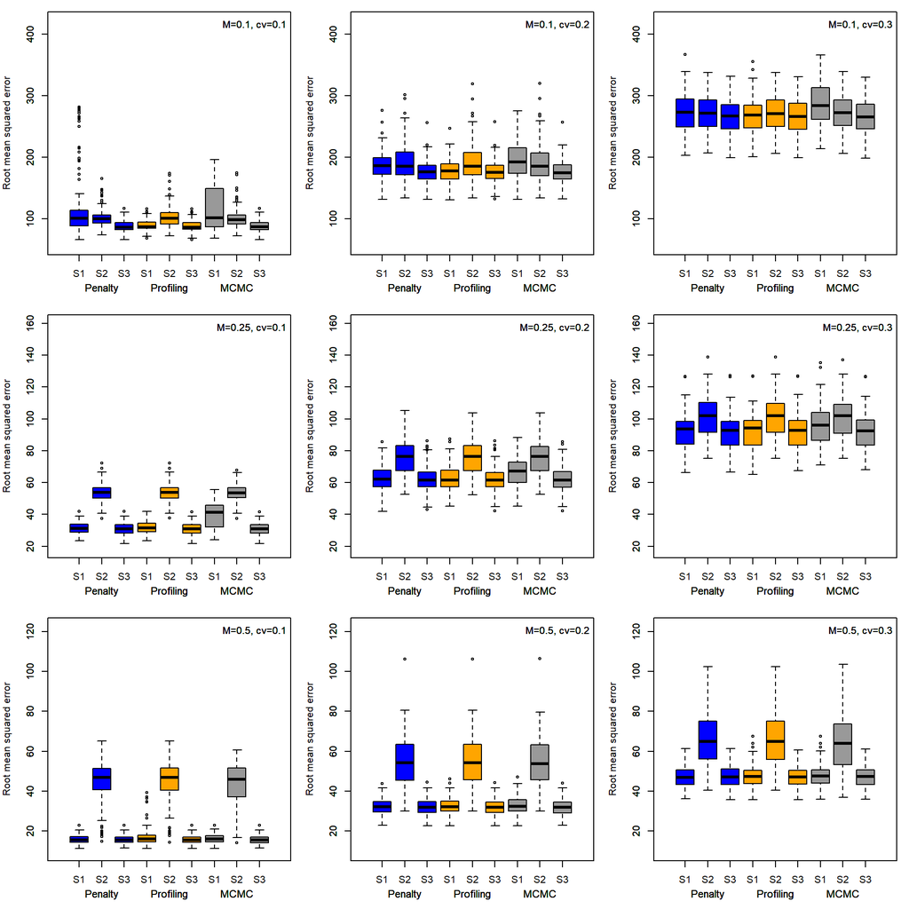

```r
xlimits <- matrix(1:Nscenario, nrow = 3, ncol = 3, byrow = TRUE)
naming <- matrix(rep(c("S1", "S2", "S3"), 3), nrow = 3, ncol = 3, byrow = TRUE)
colours <- c("blue", "orange", "grey60")
layout(matrix(1:Nscenario, nrow = 3, ncol = 3))
par(mar = c(4, 4, 1, 1))
for (s in 1:Nscenario) {
    index <- grep(paste("M=", scenario[s, 3], sep = ""), dimnames(res)$Scenario)
    for (t in 1:3) {
        if (t == 1) {
            boxplot(res[, s, t, ], at = xlimits[t, ], xlim = c(0, 10), names = naming[t,
                ], ylim = range(res[, index, , ], na.rm = T) * c(0.85, 1.15),
                ylab = "Root mean squared error", col = colours[t])
        } else {
            boxplot(res[, s, t, ], at = xlimits[t, ], names = naming[t, ], add = TRUE,
                col = colours[t])
        }
        mtext(side = 1, at = c(2, 5, 8), dimnames(res)$Technique, line = 2.25,
            cex = 0.7)
        Corner_text(dimnames(res)$Scenario[s], location = "topright")
    }
}
```

The RMSE results suggest that most of the approaches do well. Note the range of the y-axes decreases as $M$ increases, showing that increased mortality leads to reduced bias and increased precision. This is likely because the breakpoint at maturity is more easily distinguished as mortality increases (due to increased investment in reproduction; Lester, Shuter & Abrams (2004)). The *S2* starting vector was the most sensitive at high levels of mortality. As expected, RMSE increases as $cv_l$ increases.

#### Percent bias plots

Finally, we plot the bias results for each parameter.

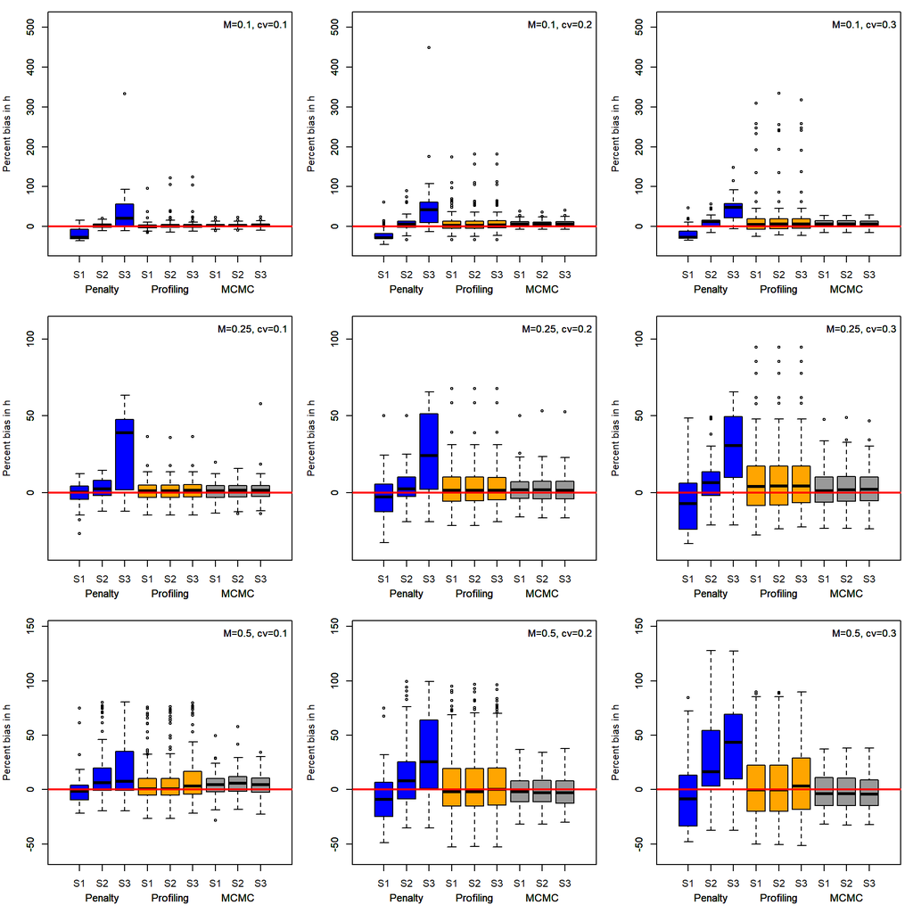

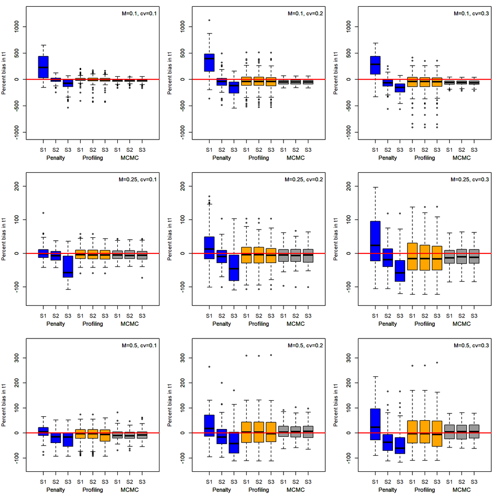

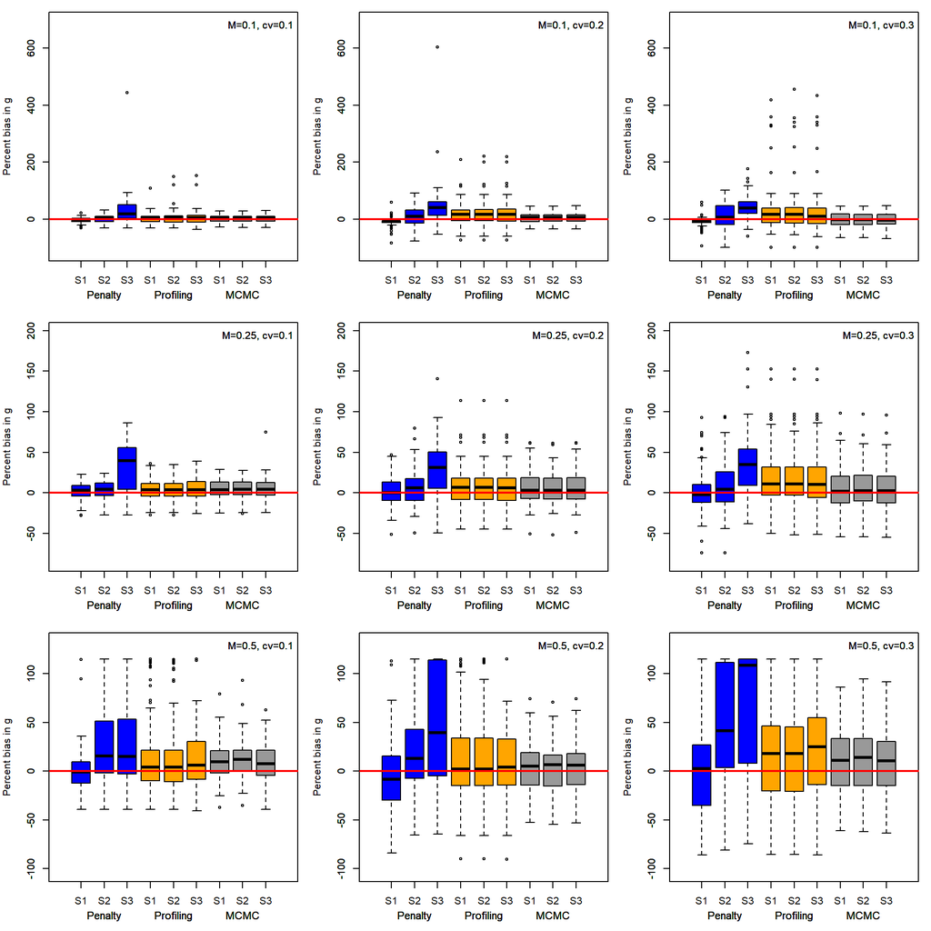

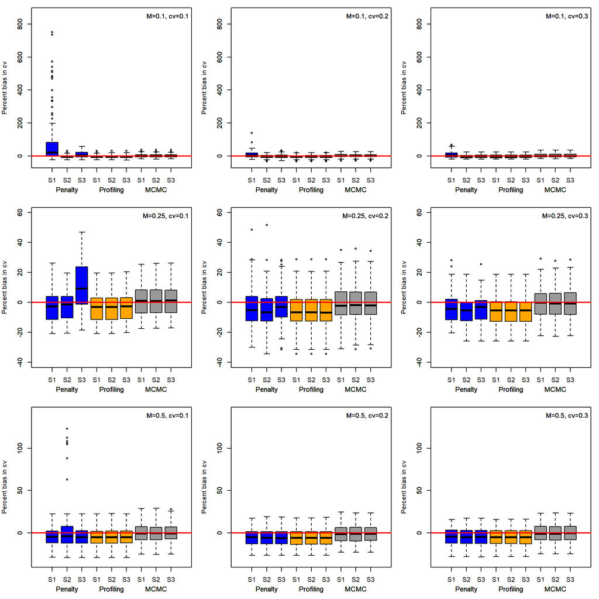

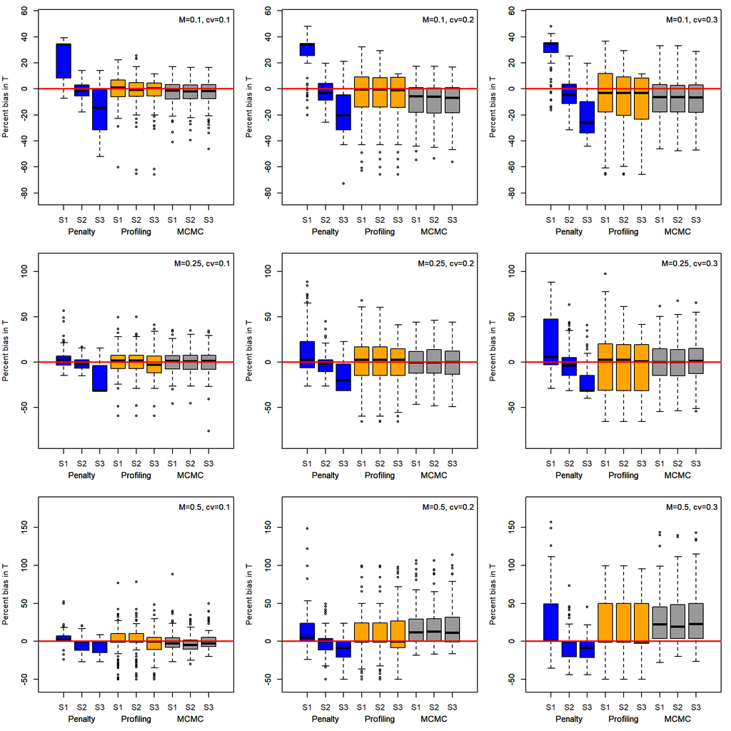

```r
xlimits <- matrix(1:Nscenario,nrow=3,ncol=3,byrow=TRUE)
naming <- matrix(rep(c("S1","S2","S3"),3),nrow=3,ncol=3,byrow=TRUE)
layout(matrix(1:Nscenario,nrow=3,ncol=3))
par(mar=c(4,4,1,1))
for(p in 1:5) # loop across the 5 life history parameters
{
  for(s in 1:Nscenario)
  {
    index <- grep(paste("M=",scenario[s,3],sep=""),dimnames(res)$Scenario)
    for(t in 1:3) # loop across the 3 methodological approaches
    {
      if(t==1){
        boxplot(bias[,s,,t,p],at=xlimits[t,],xlim=c(0,10),names=naming[t,],ylim=range(bias[,index,,,p])*1.15,ylab=paste("Percent bias in ",dimnames(bias)$Parameters[p],sep=""),col=colours[t])
        abline(h=0,col="red",lwd=2)
      }else{
        boxplot(bias[,s,,t,p],at=xlimits[t,],names=naming[t,],add=TRUE,col=colours[t])
        abline(h=0,col="red",lwd=2)
      }
      mtext(side=1,at=c(2,5,8),dimnames(bias)$Technique,line=2.25,cex=0.7)
      Corner_text(dimnames(bias)$Scenario[s],location="topright")
    }
  }
}
```

### Summary results

MCMC tended to perform the best in recovering life history parameters. The likelihood profiling also performed relatively well. The penalized likelihood approach performed well in some cases but was generally the most sensitive to starting values.

We note, however, that there were y=7 failures out of 900 successful iterations. The penalized likelihood approach accounted for most of these failures, highlighting that this approach can work but may not be as robust as the other approaches. Lastly, we note that the specification of the prior distributions can alter results and interpretation for the Bayesian MCMC approach. Having a uniform prior on $T$ increased accuracy and precision compared to a normal prior on $T$ in certain scenarios (largely when $M$ and $cv_l$ were both large).

## References

Honsey, A.E., Staples, D.F. & Venturelli, P.A. (2016). Accurate estimates of age at maturity from the growth trajectories of fishes and other ectotherms. *Ecological Applications*, **27**, 182–192.

Lester, N.P., Shuter, B.J. & Abrams, P.A. (2004). Interpreting the von bertalanffy model of somatic growth in fishes: The cost of reproduction. *Proceedings of the Royal Society B: Biological Sciences*, **271**, 1625–1631.

Ono, K., Punt, A.E. & Rivot, E. (2012). Model performance analysis for bayesian biomass dynamics models using bias, precision and reliability metrics. *Fisheries Research*, **125-126**, 173–183.

Plummer, M. (2017). JAGS: A program for analysis of bayesian graphical models using gibbs sampling.

Wilson, K.L., Honsey, A., Moe, B. & Venturelli, P. (2017). Growing the biphasic framework: techniques and recommendations for fitting emerging growth models. *Methods in Ecology and Evolution*, **In Review**.